# Viral CAI Analysis

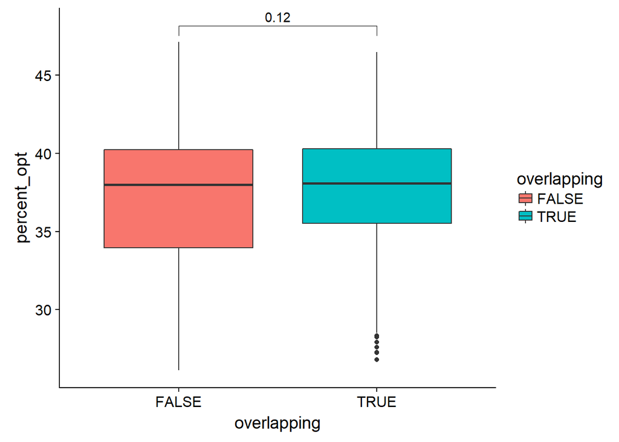

```r
virus_tidy %>% mutate(overlapping = ifelse(grepl("NA", virus_tidy$overlap, fixed = TRUE), "FALSE", "TRUE")) %>%
               ggplot(aes(overlapping, percent_opt, fill = overlapping)) +
               geom_boxplot() +
               stat_compare_means(comparisons = my_comparisons,
                                  method = "wilcox.test")
```

If we assume we are correctly defining overlapping genes, then one explanation for our results is that overlapping genes encode proteins with similar functions thus requiring similar translation efficiencies and therefore similar CAI/ percent_optimality. This however only works for genes within the same frame.

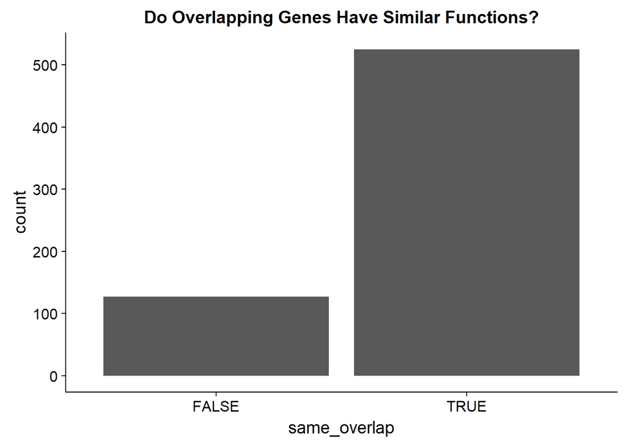

```r
neat_overlaps <- virus_tidy %>%
                 mutate(overlapping = ifelse(grepl("NA", virus_tidy$overlap, fixed = TRUE), "FALSE", "TRUE")) %>%
                 select(virus, gene, protein_type, CAI, percent_opt, overlap, overlapping, frame, strand) %>%
                 separate(overlap, into = c("E1", "E2", "E3", "E4", "E5", "E6"), sep = ", ") %>%
                 gather(c(E1, E2, E3, E4, E5, E6), key = "key", value = "overlapping_genes") %>%
                 na.omit(overlapping_genes) %>%
                 mutate(overlapping_genes = ifelse(overlapping_genes == "NA", "NA", gsub("--.*", "", .$overlapping_genes)))

x <- 1:nrow(neat_overlaps)
overlapped_protein_type <- unlist(lapply(x, function(x) ifelse(neat_overlaps$overlapping_genes[x] == "NA", "NA",
        neat_overlaps[neat_overlaps$gene %in% neat_overlaps$overlapping_genes[x], ] %>%
                  filter(virus == neat_overlaps$virus[x], key == neat_overlaps$key[x]) %>%
                  .$protein_type)))

neat_overlaps <- neat_overlaps %>% mutate(overlapping_protein_type = overlapped_protein_type,
                                          same_overlap = ifelse(overlapping_protein_type == "NA",
                                                                "NA", overlapping_protein_type == protein_type))

neat_overlaps %>% mutate(overlapping_protein_type = overlapped_protein_type,
                         same_overlap = ifelse(overlapping_protein_type == "NA",
                                               "NA", overlapping_protein_type == protein_type)) %>%
                  group_by(same_overlap) %>%
                  summarise(count = n()) %>%
                  .[c(1,3), ] %>%
                  ggplot(aes(same_overlap, count)) +
                         geom_bar(stat = "identity") +
                  labs(xlab = "Overlapping genes with same function",
                       ylab = "number of occurances",
                       title = "Do Overlapping Genes Have Similar Functions?")
```

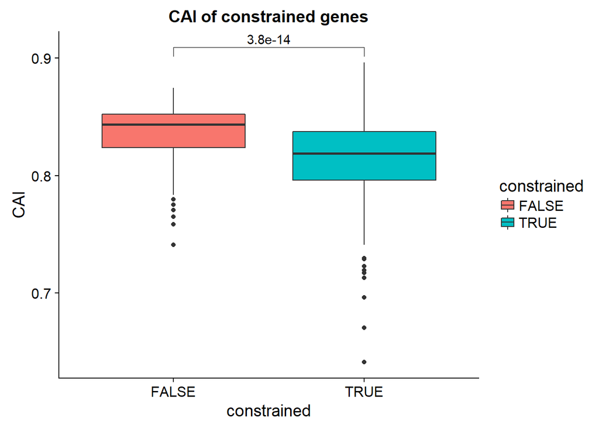

```r
x <- 1:nrow(neat_overlaps)
overlapped_frame <- unlist(lapply(x, function(x) ifelse(neat_overlaps$overlapping_genes[x] == "NA", "NA",
        neat_overlaps[neat_overlaps$gene %in% neat_overlaps$overlapping_genes[x], ] %>%
                  filter(virus == neat_overlaps$virus[x], key == neat_overlaps$key[x]) %>% .$frame)))

neat_overlaps %>% mutate(overlapping_frame = overlapped_frame,
                         constrained = ifelse(overlapping_frame == "NA", "NA", overlapping_frame != frame)) %>%
                  filter(constrained != "NA") %>%
                  ggplot(aes(constrained, CAI, fill = constrained)) +
                         geom_boxplot() +
                  labs(xlab = "Constrained Overlapping Genes",
                       title = "CAI of constrained genes") +
                  stat_compare_means(comparisons = my_comparisons,
                                     method = "wilcox.test")
```

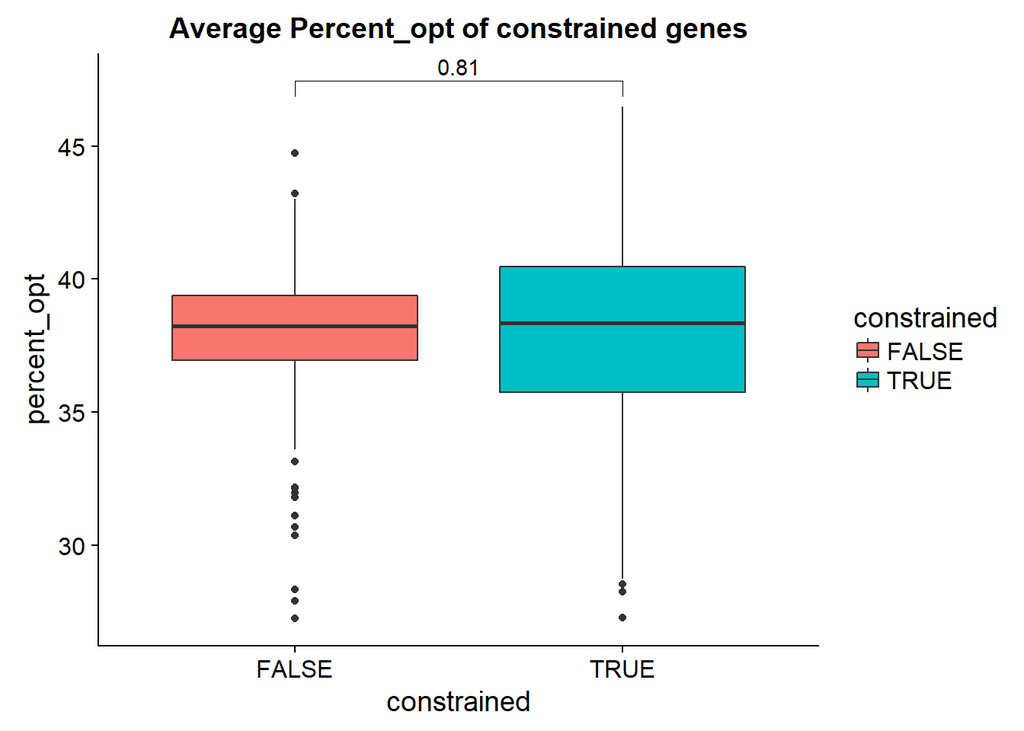

```r
neat_overlaps %>% mutate(overlapping_frame = overlapped_frame,
                         constrained = ifelse(overlapping_frame == "NA", "NA", overlapping_frame != frame)) %>%
                  filter(constrained != "NA") %>%
                  ggplot(aes(constrained, percent_opt, fill = constrained)) +
                         geom_boxplot() +
                  labs(xlab = "Constrained Overlapping Genes",
                       title = "Average Percent_opt of constrained genes") +
                  stat_compare_means(comparisons = my_comparisons,
                                     method = "wilcox.test")
```

We also hypothesized that structural protein types would have a higher CAI/ percent_opt than less abundant protein types such as enzymes or regulators. This was also unsupported by our data.

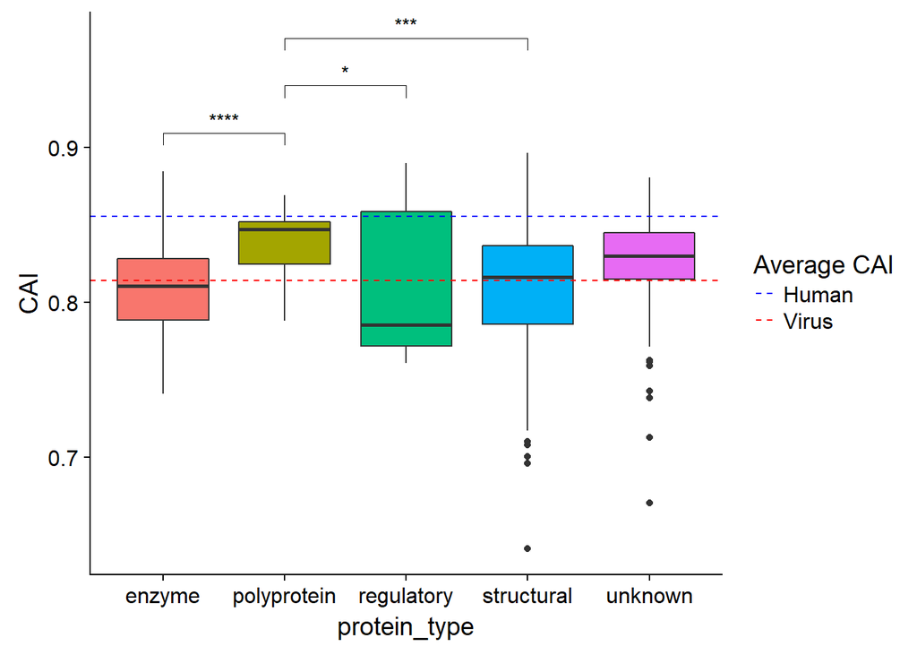

```r
my_comparisons <- list(c("enzyme", "polyprotein"), c("polyprotein", "regulatory"), c("polyprotein", "structural"))

virus_tidy %>% ggplot(aes(protein_type, CAI, fill = protein_type)) +
                      geom_boxplot() +
                      guides(fill = FALSE) +
                      geom_hline(aes(yintercept = mean(virus_tidy$CAI),
                                     linetype = "Virus"),
                                     color = "red") +
                      geom_hline(aes(yintercept = human_CAI,
                                     linetype = "Human"),
                                     color = "blue") +
                      scale_linetype_manual(name = "Average CAI",
                                            values = c(2, 2),
                                            guide = guide_legend(override.aes = list(color = c("blue", "red")))) +
                      stat_compare_means(comparisons = my_comparisons,
                                         method = "wilcox.test",
                                         label = "p.signif",
                                         hide.ns = TRUE)
```

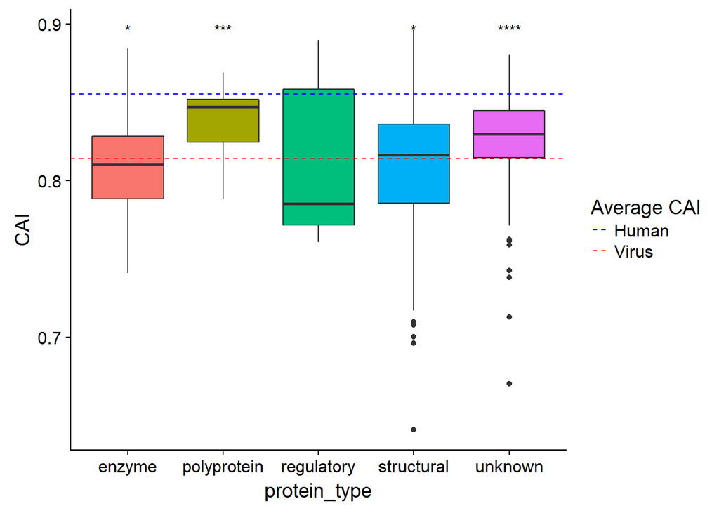

```r
virus_tidy %>% ggplot(aes(protein_type, CAI, fill = protein_type)) +
                      geom_boxplot() +
                      guides(fill = FALSE) +
                      geom_hline(aes(yintercept = mean(virus_tidy$CAI),
                                     linetype = "Virus"),
                                     color = "red") +
                      geom_hline(aes(yintercept = human_CAI,
                                     linetype = "Human"),
                                     color = "blue") +
                      scale_linetype_manual(name = "Average CAI",
                                            values = c(2, 2),
                                            guide = guide_legend(override.aes = list(color = c("blue", "red")))) +
                      stat_compare_means(method = "wilcox.test",
                                         label = "p.signif",
                                         hide.ns = TRUE,
                                         ref.group = ".all.")
```

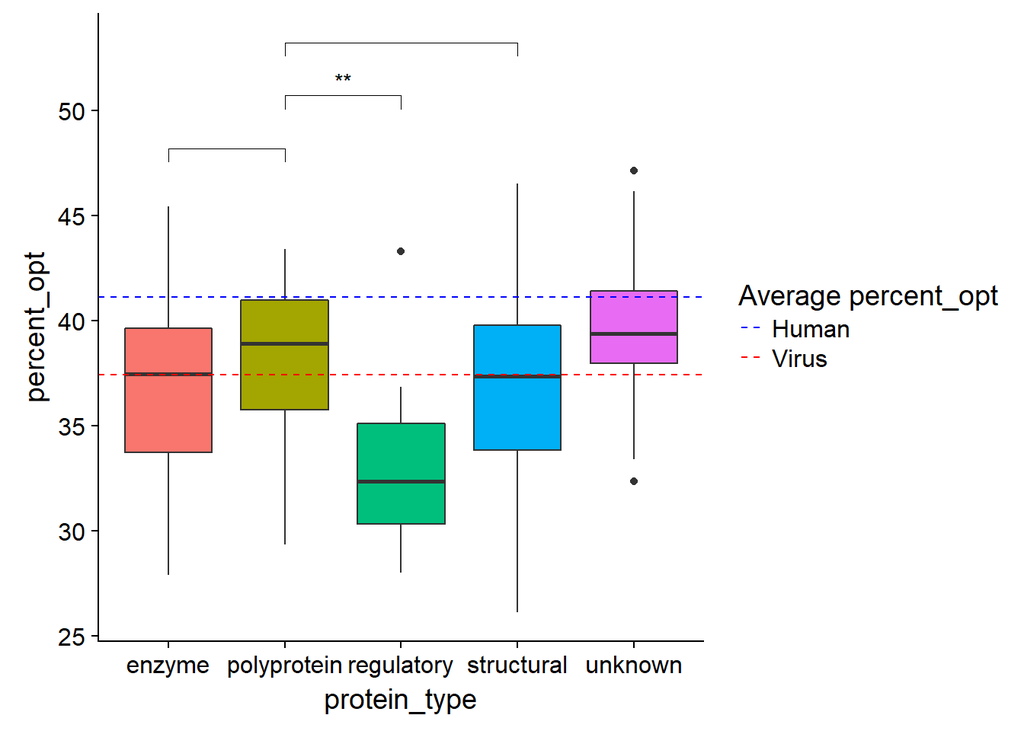

```r
virus_tidy %>% ggplot(aes(protein_type, percent_opt, fill = protein_type)) +
                      geom_boxplot() +
                      guides(fill = FALSE) +
                      geom_hline(aes(yintercept = mean(virus_tidy$percent_opt),
                                     linetype = "Virus"),
                                     color = "red") +
                      geom_hline(aes(yintercept = human_percent_opt,
                                     linetype = "Human"),
                                     color = "blue") +
                      scale_linetype_manual(name = "Average percent_opt",
                                            values = c(2, 2),
                                            guide = guide_legend(override.aes = list(color = c("blue", "red")))) +
                      stat_compare_means(comparisons = my_comparisons,
                                         method = "wilcox.test",
                                         label = "p.signif",
                                         hide.ns = TRUE)
```

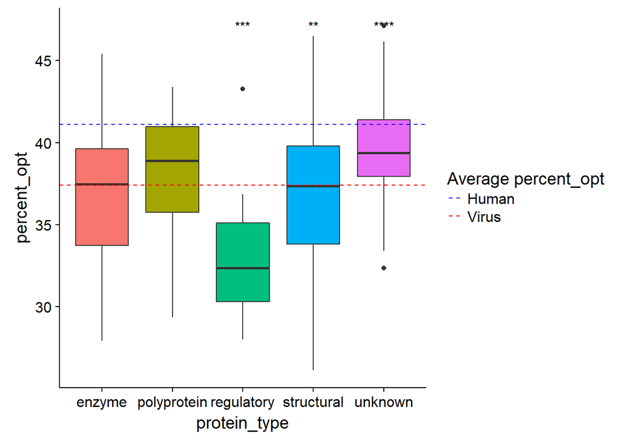

```r
virus_tidy %>% ggplot(aes(protein_type, percent_opt, fill = protein_type)) +
                      geom_boxplot() +
                      guides(fill = FALSE) +
                      geom_hline(aes(yintercept = mean(virus_tidy$percent_opt),
                                     linetype = "Virus"),
                                     color = "red") +
                      geom_hline(aes(yintercept = human_percent_opt,
                                     linetype = "Human"),
                                     color = "blue") +
                      scale_linetype_manual(name = "Average percent_opt",
                                            values = c(2, 2),
                                            guide = guide_legend(override.aes = list(color = c("blue", "red")))) +
                      stat_compare_means(method = "wilcox.test",
                                         label = "p.signif",
                                         hide.ns = TRUE,
                                         ref.group = ".all.")
```

Host types determined by virus host data base (http://www.genome.jp/virushostdb/)

| Host type | Viruses |
| --- | --- |
| Human | HSV1, HepC, HIV1, HPV, mumps, HEA, RHIV, polio, HTLV2, AdenoV, vaccina, smallpox, EBV, CMV, chickenpox, rubella, measles, rotavirus1, |
| Primate | HepB, |
| Vertebrate | H1N1, H5N1, RABV, EBOLV, cowpox, marburg |
| Vert + Invert | WNV1, DENV, CHIKV, YFV, ZIKV |

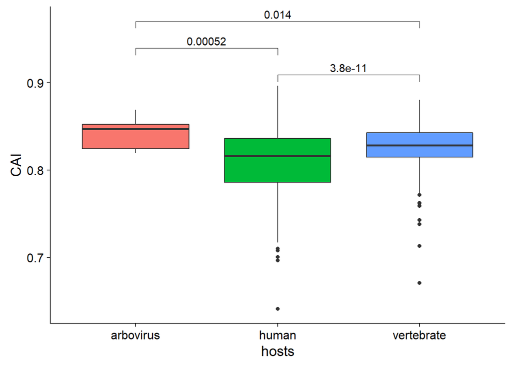

```r
Vert_INV <- c("WNV1", "DENV", "CHIKV", "YFV", "ZIKV")
Vertebrate <- c("H1N1", "H5N1", "RABV", "EBOLV", "cowpox", "marburg")

my_comparisons <- list(c("human", "vertebrate"),
                       c("human", "arbovirus"),
                       c("arbovirus", "vertebrate"))

virus_tidy %>% mutate(hosts = ifelse(virus %in% Vert_INV, "arbovirus",
                                     ifelse(virus %in% Vertebrate, "vertebrate", "human"))) %>%
               ggplot(aes(hosts, CAI, fill = hosts)) +
                      geom_boxplot() +
                      guides(fill = FALSE) +
                      stat_compare_means(comparisons = my_comparisons,
                                         method = "wilcox.test")
```

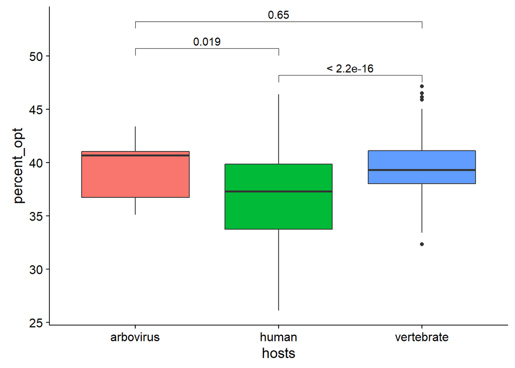

```r
virus_tidy %>% mutate(hosts = ifelse(virus %in% Vert_INV, "arbovirus",
                                     ifelse(virus %in% Vertebrate, "vertebrate", "human"))) %>%
               ggplot(aes(hosts, percent_opt, fill = hosts)) +
                      geom_boxplot() +
                      guides(fill = FALSE) +
                      stat_compare_means(comparisons = my_comparisons,
                                         method = "wilcox.test")
```

Instead of overall CAI or percent_opt of a transcript determining it’s translational efficiency, the longest stretch of non-optimal codons could play a stronger role in slowing or speeding the ribosome.

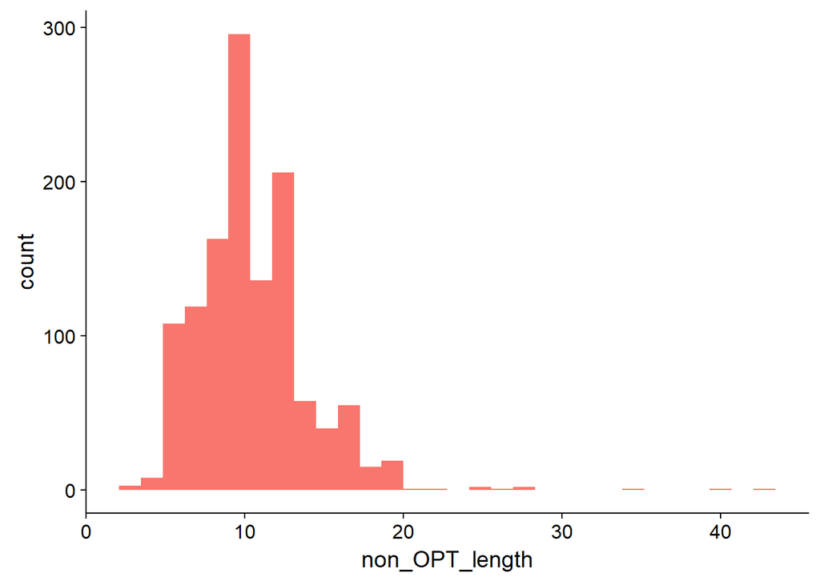

```r
virus_tidy %>% ggplot(aes(non_OPT_length, fill = "red")) +
                      geom_histogram() +
                      guides(fill = FALSE)
```

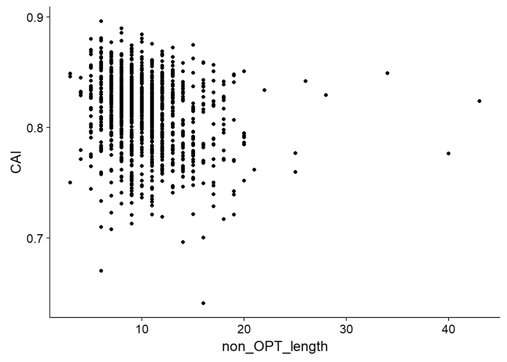

```r
virus_tidy %>% ggplot(aes(non_OPT_length, CAI)) + geom_point()
```

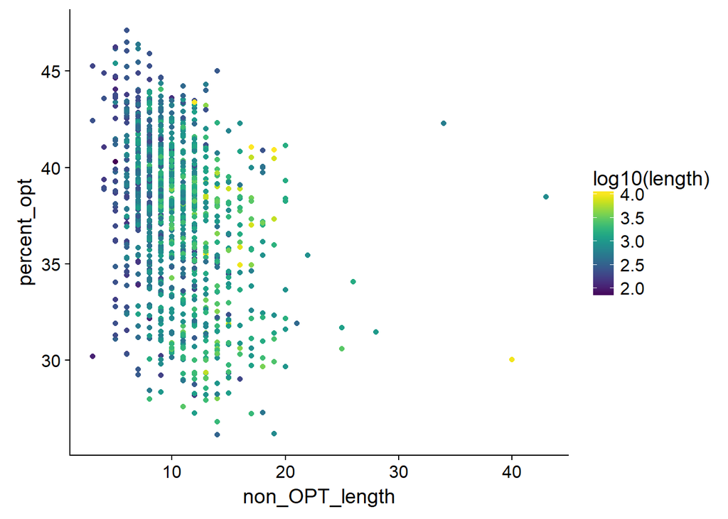

```r
virus_tidy %>% ggplot(aes(non_OPT_length, percent_opt, col = log10(length))) + geom_point() + scale_color_viridis()
```

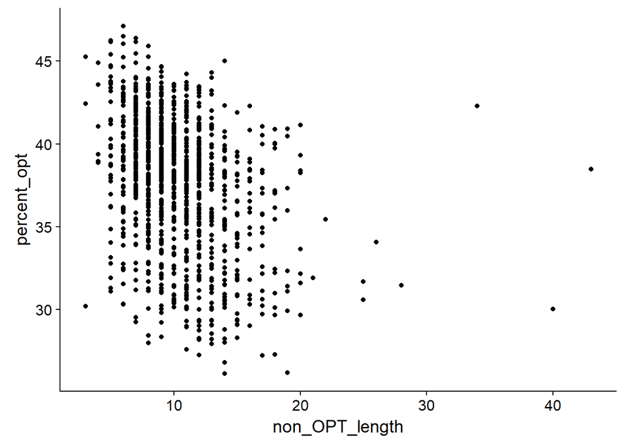

```r
virus_tidy %>% ggplot(aes(non_OPT_length, percent_opt)) + geom_point()
```

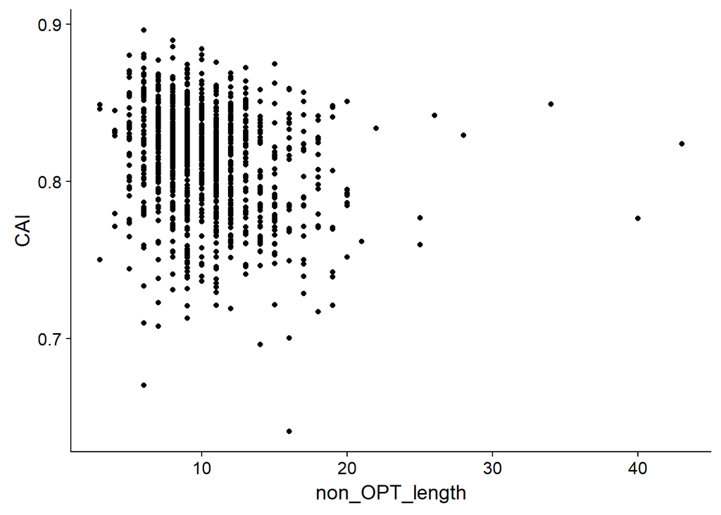

```r
virus_tidy %>% ggplot(aes(non_OPT_length, CAI)) + geom_point()
```

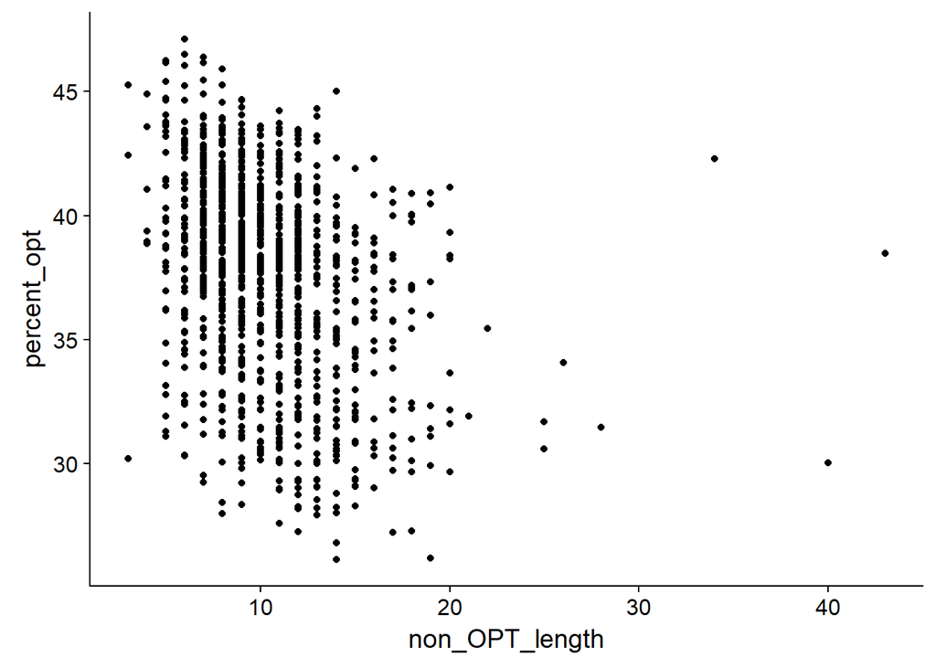

```r
virus_tidy %>% ggplot(aes(non_OPT_length, percent_opt)) + geom_point()
```

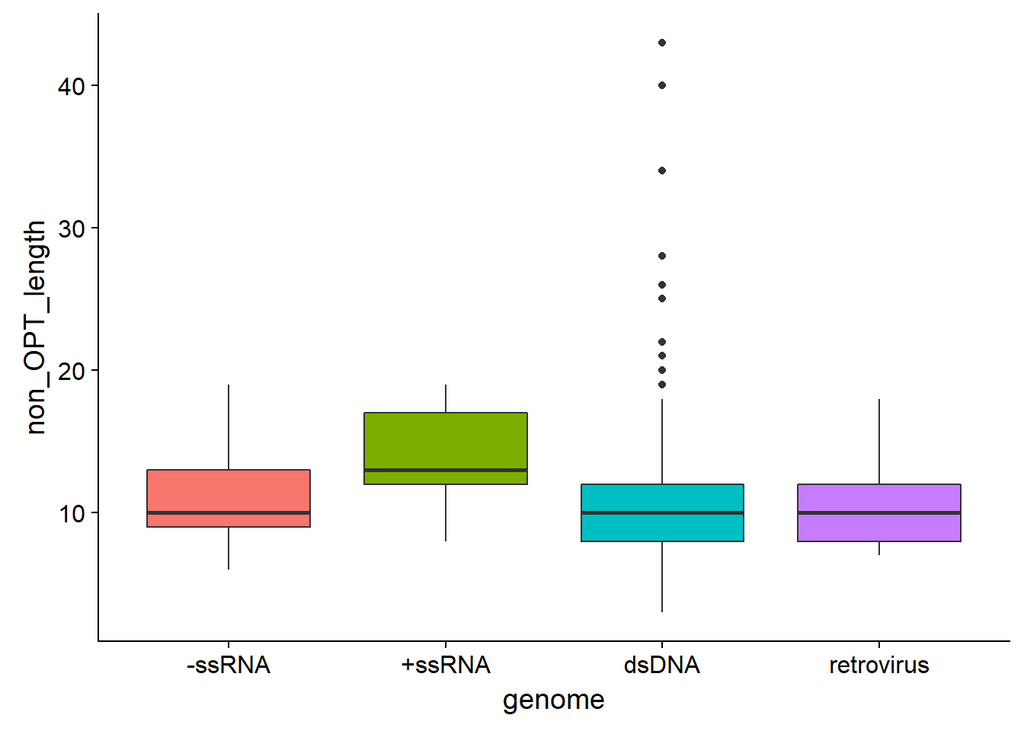

```r
virus_tidy %>% ggplot(aes(genome, non_OPT_length, fill = genome)) + geom_boxplot() + guides(fill = FALSE)
```

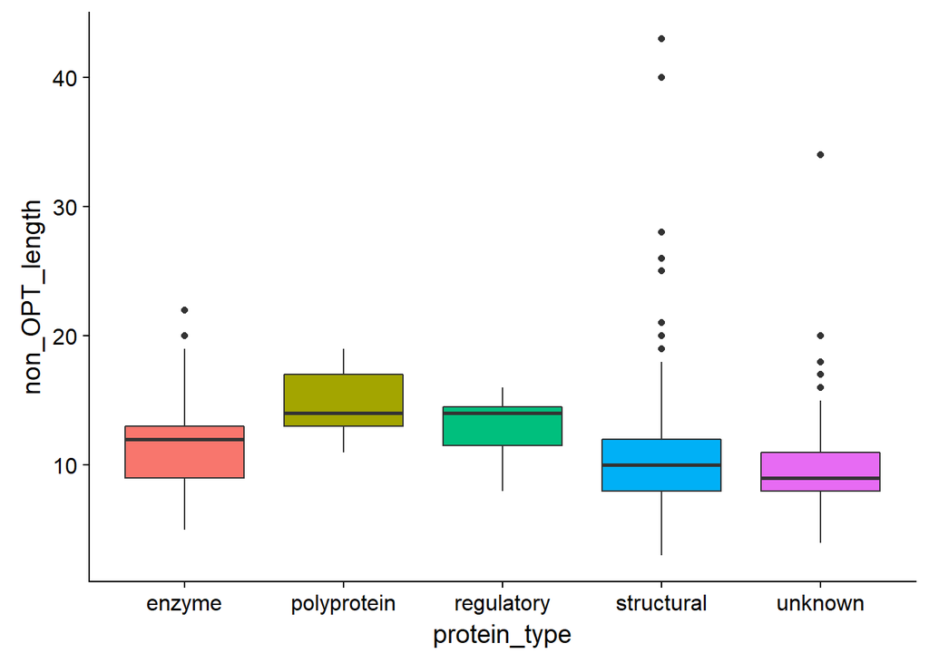

```r
virus_tidy %>% ggplot(aes(protein_type, non_OPT_length, fill = protein_type)) + geom_boxplot() + guides(fill = FALSE)
```

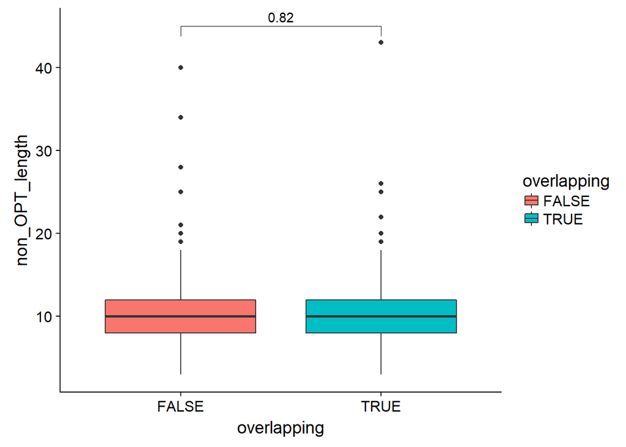

```r
my_comparisons <- list(c("FALSE", "TRUE"))

virus_tidy %>% mutate(overlapping = ifelse(grepl("NA", virus_tidy$overlap, fixed = TRUE), "FALSE", "TRUE")) %>%
               ggplot(aes(overlapping, non_OPT_length, fill = overlapping)) +
               geom_boxplot() +
               stat_compare_means(comparisons = my_comparisons,
                                  method = "wilcox.test")
```

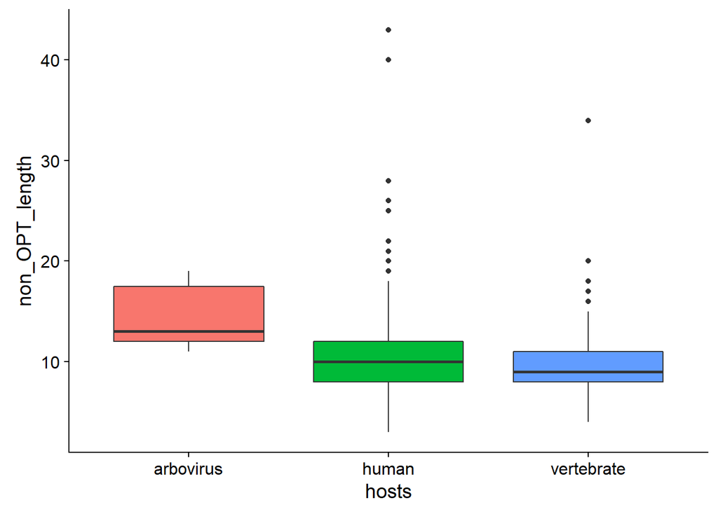

```r
virus_tidy %>% mutate(hosts = ifelse(virus %in% Vert_INV, "arbovirus",
                                     ifelse(virus %in% Vertebrate, "vertebrate", "human"))) %>%
               ggplot(aes(hosts, non_OPT_length, fill = hosts)) +
               geom_boxplot() +
               guides(fill = FALSE)
```

### General Comparisons of the Viruses

```r
virus_tidy  %>% group_by(virus) %>%
                summarise_at(.vars = vars(CAI, percent_opt, GC), .funs = mean) %>%
                arrange(CAI)
```

```
## # A tibble: 30 x 4
##    virus        CAI percent_opt    GC
##    <chr>      <dbl>       <dbl> <dbl>
##  1 HSV1       0.780        30.9 0.679
##  2 CMV        0.781        32.9 0.572
##  3 chickenpox 0.783        36.3 0.465
##  4 rubella    0.797        29.8 0.697
##  5 HepC       0.815        32.4 0.594
##  6 HepB       0.819        37.4 0.500
##  7 CHIKV      0.823        35.9 0.514
##  8 cowpox     0.824        39.5 0.342
##  9 rotavirus1 0.824        41.6 0.329
## 10 vaccina    0.825        39.3 0.346
## # ... with 20 more rows
```

```r
virus_tidy  %>% group_by(genome) %>%
                summarise_at(.vars = vars(CAI, percent_opt, GC), .funs = mean) %>%
                arrange(CAI)
```

```
## # A tibble: 4 x 4
##   genome       CAI percent_opt    GC
##   <chr>      <dbl>       <dbl> <dbl>
## 1 dsDNA      0.812        37.3 0.441
## 2 +ssRNA     0.836        37.5 0.530
## 3 -ssRNA     0.838        38.7 0.457
## 4 retrovirus 0.842        39.3 0.481
```

```r
virus_tidy  %>% group_by(protein_type) %>%
                summarise_at(.vars = vars(CAI, percent_opt, GC), .funs = mean) %>%
                arrange(CAI)
```

```
## # A tibble: 5 x 4
##   protein_type   CAI percent_opt    GC
##   <chr>        <dbl>       <dbl> <dbl>
## 1 regulatory   0.806        33.8 0.630
## 2 enzyme       0.810        36.7 0.458
## 3 structural   0.810        36.9 0.464
## 4 unknown      0.827        39.5 0.359
## 5 polyprotein  0.838        38.1 0.521
```

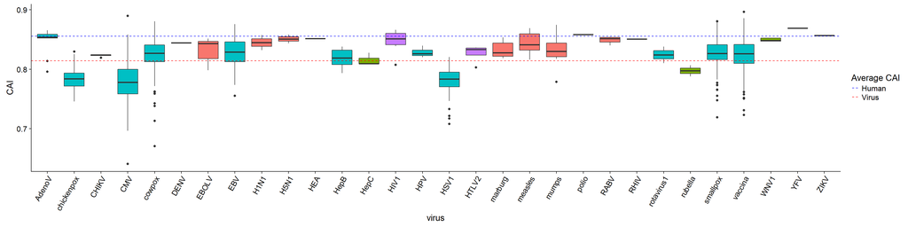

```r
virus_tidy %>% ggplot(aes(virus, CAI, fill = genome)) +
                      geom_boxplot() +
                      theme(axis.text.x = element_text(angle=60, hjust=1)) +
                      guides(fill = FALSE) +
                      geom_hline(aes(yintercept = mean(virus_tidy$CAI),
                                     linetype = "Virus"),
                                     color = "red") +
                      geom_hline(aes(yintercept = human_CAI,
                                     linetype = "Human"),
                                     color = "blue") +
                      scale_linetype_manual(name = "Average CAI",
                                            values = c(2, 2),
                                            guide = guide_legend(override.aes = list(color = c("blue", "red"))))
```

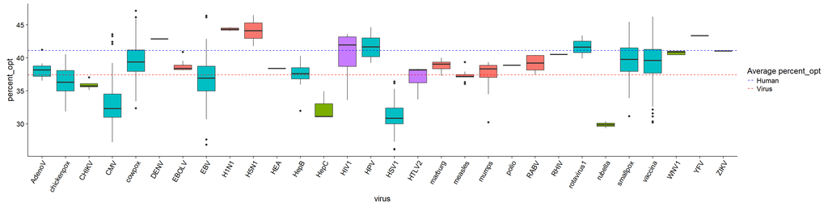

```r
virus_tidy %>% ggplot(aes(virus, percent_opt, fill = genome)) +
                      geom_boxplot() +
                      theme(axis.text.x = element_text(angle=60, hjust=1)) +
                      guides(fill = FALSE) +
                      geom_hline(aes(yintercept = mean(virus_tidy$percent_opt),
                                     linetype = "Virus"),
                                     color = "red") +
                      geom_hline(aes(yintercept = human_percent_opt,
                                     linetype = "Human"),
                                     color = "blue") +
                      scale_linetype_manual(name = "Average percent_opt",
                                            values = c(2, 2),
                                            guide = guide_legend(override.aes = list(color = c("blue", "red"))))
```